# Risk Factor Analysis

## Outcome Variable

**Outcome Variable:** y_rate_len

## Predictor Variables

**Intervention Variable:** pers_wast

**Adjustment Set:**

- arm
- sex
- W_mage
- meducyrs
- W_mhtcm
- W_nrooms
- month
- brthmon
- impfloor
- delta_W_mage
- delta_meducyrs
- delta_W_mhtcm
- delta_W_nrooms
- delta_month
- delta_brthmon
- delta_impfloor

## Stratifying Variables

The analysis was stratified on these variable(s):

- agecat
- studyid
- country

## Data Summary

| agecat | studyid | country | pers_wast | n_cell | n |
| --- | --- | --- | --- | --- | --- |
| 0-3 months | ki0047075b-MAL-ED | BANGLADESH | 0 | 237 | 244 |
| 0-3 months | ki0047075b-MAL-ED | BANGLADESH | 1 | 7 | 244 |
| 0-3 months | ki1017093b-PROVIDE | BANGLADESH | 0 | 619 | 634 |
| 0-3 months | ki1017093b-PROVIDE | BANGLADESH | 1 | 15 | 634 |
| 0-3 months | ki1114097-CMIN | BANGLADESH | 0 | 41 | 43 |
| 0-3 months | ki1114097-CMIN | BANGLADESH | 1 | 2 | 43 |
| 0-3 months | ki0047075b-MAL-ED | BRAZIL | 0 | 180 | 180 |
| 0-3 months | ki1101329-Keneba | GAMBIA | 0 | 1246 | 1276 |
| 0-3 months | ki1101329-Keneba | GAMBIA | 1 | 30 | 1276 |
| 0-3 months | ki0047075b-MAL-ED | INDIA | 0 | 187 | 201 |
| 0-3 months | ki0047075b-MAL-ED | INDIA | 1 | 14 | 201 |
| 0-3 months | ki1000108-CMC-V-BCS-2002 | INDIA | 0 | 78 | 87 |
| 0-3 months | ki1000108-CMC-V-BCS-2002 | INDIA | 1 | 9 | 87 |
| 0-3 months | ki1000108-IRC | INDIA | 0 | 310 | 377 |
| 0-3 months | ki1000108-IRC | INDIA | 1 | 67 | 377 |
| 0-3 months | ki0047075b-MAL-ED | NEPAL | 0 | 172 | 175 |
| 0-3 months | ki0047075b-MAL-ED | NEPAL | 1 | 3 | 175 |
| 0-3 months | ki1000109-EE | PAKISTAN | 0 | 277 | 297 |
| 0-3 months | ki1000109-EE | PAKISTAN | 1 | 20 | 297 |
| 0-3 months | ki1000109-ResPak | PAKISTAN | 0 | 69 | 78 |
| 0-3 months | ki1000109-ResPak | PAKISTAN | 1 | 9 | 78 |
| 0-3 months | ki0047075b-MAL-ED | PERU | 0 | 271 | 271 |
| 0-3 months | ki1114097-CMIN | PERU | 0 | 89 | 93 |
| 0-3 months | ki1114097-CMIN | PERU | 1 | 4 | 93 |
| 0-3 months | ki1114097-CONTENT | PERU | 0 | 29 | 29 |
| 0-3 months | ki0047075b-MAL-ED | SOUTH AFRICA | 0 | 227 | 229 |
| 0-3 months | ki0047075b-MAL-ED | SOUTH AFRICA | 1 | 2 | 229 |
| 0-3 months | ki0047075b-MAL-ED | TANZANIA, UNITED REPUBLIC OF | 0 | 229 | 229 |
| 3-6 months | ki0047075b-MAL-ED | BANGLADESH | 0 | 226 | 231 |
| 3-6 months | ki0047075b-MAL-ED | BANGLADESH | 1 | 5 | 231 |

[output cut: 94 more lines]

The following strata were considered:

- agecat: 0-3 months, studyid: ki0047075b-MAL-ED, country: BANGLADESH
- agecat: 0-3 months, studyid: ki0047075b-MAL-ED, country: BRAZIL
- agecat: 0-3 months, studyid: ki0047075b-MAL-ED, country: INDIA
- agecat: 0-3 months, studyid: ki0047075b-MAL-ED, country: NEPAL
- agecat: 0-3 months, studyid: ki0047075b-MAL-ED, country: PERU
- agecat: 0-3 months, studyid: ki0047075b-MAL-ED, country: SOUTH AFRICA
- agecat: 0-3 months, studyid: ki0047075b-MAL-ED, country: TANZANIA, UNITED REPUBLIC OF
- agecat: 0-3 months, studyid: ki1000108-CMC-V-BCS-2002, country: INDIA
- agecat: 0-3 months, studyid: ki1000108-IRC, country: INDIA
- agecat: 0-3 months, studyid: ki1000109-EE, country: PAKISTAN
- agecat: 0-3 months, studyid: ki1000109-ResPak, country: PAKISTAN
- agecat: 0-3 months, studyid: ki1017093b-PROVIDE, country: BANGLADESH
- agecat: 0-3 months, studyid: ki1101329-Keneba, country: GAMBIA
- agecat: 0-3 months, studyid: ki1114097-CMIN, country: BANGLADESH
- agecat: 0-3 months, studyid: ki1114097-CMIN, country: PERU
- agecat: 0-3 months, studyid: ki1114097-CONTENT, country: PERU
- agecat: 12-24 months, studyid: ki0047075b-MAL-ED, country: BANGLADESH
- agecat: 12-24 months, studyid: ki0047075b-MAL-ED, country: BRAZIL
- agecat: 12-24 months, studyid: ki0047075b-MAL-ED, country: INDIA
- agecat: 12-24 months, studyid: ki0047075b-MAL-ED, country: NEPAL
- agecat: 12-24 months, studyid: ki0047075b-MAL-ED, country: PERU
- agecat: 12-24 months, studyid: ki0047075b-MAL-ED, country: SOUTH AFRICA
- agecat: 12-24 months, studyid: ki0047075b-MAL-ED, country: TANZANIA, UNITED REPUBLIC OF
- agecat: 12-24 months, studyid: ki1000108-CMC-V-BCS-2002, country: INDIA
- agecat: 12-24 months, studyid: ki1000108-IRC, country: INDIA
- agecat: 12-24 months, studyid: ki1017093b-PROVIDE, country: BANGLADESH
- agecat: 12-24 months, studyid: ki1066203-TanzaniaChild2, country: TANZANIA, UNITED REPUBLIC OF
- agecat: 12-24 months, studyid: ki1101329-Keneba, country: GAMBIA
- agecat: 12-24 months, studyid: ki1113344-GMS-Nepal, country: NEPAL
- agecat: 12-24 months, studyid: ki1114097-CMIN, country: BANGLADESH
- agecat: 12-24 months, studyid: ki1114097-CMIN, country: PERU
- agecat: 12-24 months, studyid: ki1114097-CONTENT, country: PERU
- agecat: 3-6 months, studyid: ki0047075b-MAL-ED, country: BANGLADESH
- agecat: 3-6 months, studyid: ki0047075b-MAL-ED, country: BRAZIL
- agecat: 3-6 months, studyid: ki0047075b-MAL-ED, country: INDIA
- agecat: 3-6 months, studyid: ki0047075b-MAL-ED, country: NEPAL
- agecat: 3-6 months, studyid: ki0047075b-MAL-ED, country: PERU
- agecat: 3-6 months, studyid: ki0047075b-MAL-ED, country: SOUTH AFRICA
- agecat: 3-6 months, studyid: ki0047075b-MAL-ED, country: TANZANIA, UNITED REPUBLIC OF
- agecat: 3-6 months, studyid: ki1000108-CMC-V-BCS-2002, country: INDIA
- agecat: 3-6 months, studyid: ki1000108-IRC, country: INDIA
- agecat: 3-6 months, studyid: ki1000109-EE, country: PAKISTAN
- agecat: 3-6 months, studyid: ki1000109-ResPak, country: PAKISTAN
- agecat: 3-6 months, studyid: ki1017093b-PROVIDE, country: BANGLADESH
- agecat: 3-6 months, studyid: ki1066203-TanzaniaChild2, country: TANZANIA, UNITED REPUBLIC OF
- agecat: 3-6 months, studyid: ki1101329-Keneba, country: GAMBIA
- agecat: 3-6 months, studyid: ki1113344-GMS-Nepal, country: NEPAL
- agecat: 3-6 months, studyid: ki1114097-CMIN, country: BANGLADESH
- agecat: 3-6 months, studyid: ki1114097-CMIN, country: PERU
- agecat: 3-6 months, studyid: ki1114097-CONTENT, country: PERU
- agecat: 6-12 months, studyid: ki0047075b-MAL-ED, country: BANGLADESH
- agecat: 6-12 months, studyid: ki0047075b-MAL-ED, country: BRAZIL
- agecat: 6-12 months, studyid: ki0047075b-MAL-ED, country: INDIA
- agecat: 6-12 months, studyid: ki0047075b-MAL-ED, country: NEPAL
- agecat: 6-12 months, studyid: ki0047075b-MAL-ED, country: PERU
- agecat: 6-12 months, studyid: ki0047075b-MAL-ED, country: SOUTH AFRICA
- agecat: 6-12 months, studyid: ki0047075b-MAL-ED, country: TANZANIA, UNITED REPUBLIC OF
- agecat: 6-12 months, studyid: ki1000108-CMC-V-BCS-2002, country: INDIA
- agecat: 6-12 months, studyid: ki1000108-IRC, country: INDIA
- agecat: 6-12 months, studyid: ki1000109-EE, country: PAKISTAN
- agecat: 6-12 months, studyid: ki1000109-ResPak, country: PAKISTAN
- agecat: 6-12 months, studyid: ki1017093b-PROVIDE, country: BANGLADESH
- agecat: 6-12 months, studyid: ki1066203-TanzaniaChild2, country: TANZANIA, UNITED REPUBLIC OF
- agecat: 6-12 months, studyid: ki1101329-Keneba, country: GAMBIA
- agecat: 6-12 months, studyid: ki1112895-Guatemala BSC, country: GUATEMALA
- agecat: 6-12 months, studyid: ki1113344-GMS-Nepal, country: NEPAL
- agecat: 6-12 months, studyid: ki1114097-CMIN, country: BANGLADESH
- agecat: 6-12 months, studyid: ki1114097-CMIN, country: PERU
- agecat: 6-12 months, studyid: ki1114097-CONTENT, country: PERU

### Dropped Strata

Some strata were dropped due to rare outcomes:

- agecat: 0-3 months, studyid: ki1114097-CMIN, country: BANGLADESH
- agecat: 0-3 months, studyid: ki0047075b-MAL-ED, country: NEPAL
- agecat: 0-3 months, studyid: ki1114097-CMIN, country: PERU
- agecat: 0-3 months, studyid: ki0047075b-MAL-ED, country: SOUTH AFRICA
- agecat: 3-6 months, studyid: ki0047075b-MAL-ED, country: BRAZIL
- agecat: 3-6 months, studyid: ki0047075b-MAL-ED, country: NEPAL
- agecat: 3-6 months, studyid: ki0047075b-MAL-ED, country: SOUTH AFRICA
- agecat: 6-12 months, studyid: ki0047075b-MAL-ED, country: BRAZIL
- agecat: 6-12 months, studyid: ki1112895-Guatemala BSC, country: GUATEMALA
- agecat: 6-12 months, studyid: ki0047075b-MAL-ED, country: NEPAL
- agecat: 6-12 months, studyid: ki1000109-EE, country: PAKISTAN
- agecat: 6-12 months, studyid: ki0047075b-MAL-ED, country: SOUTH AFRICA
- agecat: 12-24 months, studyid: ki1114097-CMIN, country: BANGLADESH
- agecat: 12-24 months, studyid: ki0047075b-MAL-ED, country: BRAZIL
- agecat: 12-24 months, studyid: ki0047075b-MAL-ED, country: NEPAL
- agecat: 12-24 months, studyid: ki1114097-CMIN, country: PERU
- agecat: 12-24 months, studyid: ki0047075b-MAL-ED, country: SOUTH AFRICA
- agecat: 12-24 months, studyid: ki1066203-TanzaniaChild2, country: TANZANIA, UNITED REPUBLIC OF

## Methods Detail

We’re interested in the causal parameters $E[Y_a]$ for all values of $a \in \mathcal{A}$. These parameters represent the mean outcome if, possibly contrary to fact, we intervened to set all units to have $A=a$. Under the randomization and positivity assumptions, these are identified by the statistical parameters $\psi_a=E_W[E_{Y|A,W}(Y|A=a,W)]$. In addition, we’re interested in the mean of $Y$, $E[Y]$ under no intervention (the observed mean). We will estimate these parameters by using SuperLearner to fit the relevant likelihood factors – $E_{Y|A,W}(Y|A=a,W)$ and $p(A=a|W)$, and then updating our likelihood fit using a joint TMLE.

For unadjusted analyses ($W=\{\}$), initial likelihoods were estimated using Lrnr_glm to estimate the simple $E(Y|A)$ and Lrnr_mean to estimate $p(A)$. For adjusted analyses, a small library containing Lrnr_glmnet, Lrnr_xgboost, and Lrnr_mean was used.

[output not shown]

[output cut: 2237 more lines]

[output not shown]

# Results Detail

## Results Plots

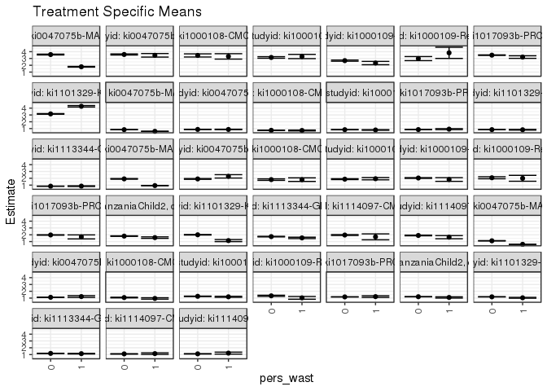

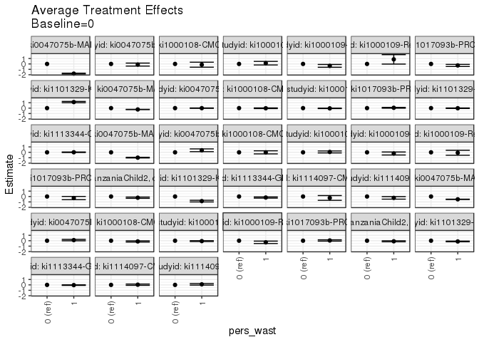

## Results Table

### Parameter: TSM

| agecat | studyid | country | intervention_level | baseline_level | estimate | ci_lower | ci_upper |
| --- | --- | --- | --- | --- | --- | --- | --- |
| 0-3 months | ki0047075b-MAL-ED | BANGLADESH | 0 | NA | 3.5743168 | 3.5121703 | 3.6364633 |
| 0-3 months | ki0047075b-MAL-ED | BANGLADESH | 1 | NA | 1.7792558 | 1.7229609 | 1.8355507 |
| 0-3 months | ki0047075b-MAL-ED | INDIA | 0 | NA | 3.5846983 | 3.5025082 | 3.6668884 |
| 0-3 months | ki0047075b-MAL-ED | INDIA | 1 | NA | 3.4662950 | 3.2035236 | 3.7290664 |
| 0-3 months | ki1000108-CMC-V-BCS-2002 | INDIA | 0 | NA | 3.4467474 | 3.2170594 | 3.6764353 |
| 0-3 months | ki1000108-CMC-V-BCS-2002 | INDIA | 1 | NA | 3.3047304 | 2.9055621 | 3.7038987 |
| 0-3 months | ki1000108-IRC | INDIA | 0 | NA | 3.1484349 | 3.0333192 | 3.2635506 |
| 0-3 months | ki1000108-IRC | INDIA | 1 | NA | 3.2881483 | 2.9760012 | 3.6002954 |
| 0-3 months | ki1000109-EE | PAKISTAN | 0 | NA | 2.6815924 | 2.5944247 | 2.7687600 |
| 0-3 months | ki1000109-EE | PAKISTAN | 1 | NA | 2.3247779 | 2.0806681 | 2.5688877 |
| 0-3 months | ki1000109-ResPak | PAKISTAN | 0 | NA | 2.9805159 | 2.6831360 | 3.2778958 |
| 0-3 months | ki1000109-ResPak | PAKISTAN | 1 | NA | 3.8268445 | 3.0058563 | 4.6478326 |
| 0-3 months | ki1017093b-PROVIDE | BANGLADESH | 0 | NA | 3.4866405 | 3.4472983 | 3.5259827 |
| 0-3 months | ki1017093b-PROVIDE | BANGLADESH | 1 | NA | 3.2069887 | 3.0180891 | 3.3958882 |
| 0-3 months | ki1101329-Keneba | GAMBIA | 0 | NA | 3.1569326 | 3.1100342 | 3.2038311 |
| 0-3 months | ki1101329-Keneba | GAMBIA | 1 | NA | 4.2739899 | 4.1683702 | 4.3796096 |
| 3-6 months | ki0047075b-MAL-ED | BANGLADESH | 0 | NA | 1.9107870 | 1.8593637 | 1.9622103 |
| 3-6 months | ki0047075b-MAL-ED | BANGLADESH | 1 | NA | 0.9261546 | 0.9038003 | 0.9485088 |
| 3-6 months | ki0047075b-MAL-ED | INDIA | 0 | NA | 1.9032792 | 1.8419607 | 1.9645977 |
| 3-6 months | ki0047075b-MAL-ED | INDIA | 1 | NA | 2.2802510 | 2.0338617 | 2.5266404 |
| 3-6 months | ki1000108-CMC-V-BCS-2002 | INDIA | 0 | NA | 1.8045005 | 1.6953739 | 1.9136272 |
| 3-6 months | ki1000108-CMC-V-BCS-2002 | INDIA | 1 | NA | 1.7995295 | 1.5362499 | 2.0628091 |
| 3-6 months | ki1000108-IRC | INDIA | 0 | NA | 1.8692936 | 1.8008905 | 1.9376967 |
| 3-6 months | ki1000108-IRC | INDIA | 1 | NA | 1.9356579 | 1.7687036 | 2.1026122 |
| 3-6 months | ki1000109-EE | PAKISTAN | 0 | NA | 2.0386141 | 1.9771337 | 2.1000946 |
| 3-6 months | ki1000109-EE | PAKISTAN | 1 | NA | 1.8205039 | 1.5493771 | 2.0916307 |
| 3-6 months | ki1000109-ResPak | PAKISTAN | 0 | NA | 2.0766833 | 1.9269094 | 2.2264572 |
| 3-6 months | ki1000109-ResPak | PAKISTAN | 1 | NA | 1.9942488 | 1.5611362 | 2.4273614 |
| 3-6 months | ki1017093b-PROVIDE | BANGLADESH | 0 | NA | 1.9724517 | 1.9375279 | 2.0073755 |
| 3-6 months | ki1017093b-PROVIDE | BANGLADESH | 1 | NA | 1.6863955 | 1.3890826 | 1.9837084 |
| 3-6 months | ki1066203-TanzaniaChild2 | TANZANIA, UNITED REPUBLIC OF | 0 | NA | 1.8045201 | 1.7683708 | 1.8406695 |
| 3-6 months | ki1066203-TanzaniaChild2 | TANZANIA, UNITED REPUBLIC OF | 1 | NA | 1.5825538 | 1.4692962 | 1.6958114 |
| 3-6 months | ki1101329-Keneba | GAMBIA | 0 | NA | 1.9970872 | 1.9579240 | 2.0362503 |
| 3-6 months | ki1101329-Keneba | GAMBIA | 1 | NA | 1.1461504 | 0.9967381 | 1.2955628 |
| 3-6 months | ki1113344-GMS-Nepal | NEPAL | 0 | NA | 1.7297538 | 1.6881224 | 1.7713852 |
| 3-6 months | ki1113344-GMS-Nepal | NEPAL | 1 | NA | 1.5412658 | 1.4394495 | 1.6430820 |
| 3-6 months | ki1114097-CMIN | BANGLADESH | 0 | NA | 1.9618601 | 1.8925257 | 2.0311944 |
| 3-6 months | ki1114097-CMIN | BANGLADESH | 1 | NA | 1.6961271 | 1.2587338 | 2.1335203 |
| 3-6 months | ki1114097-CMIN | PERU | 0 | NA | 1.8984851 | 1.8503338 | 1.9466365 |
| 3-6 months | ki1114097-CMIN | PERU | 1 | NA | 1.6466179 | 1.4166084 | 1.8766274 |
| 6-12 months | ki0047075b-MAL-ED | BANGLADESH | 0 | NA | 1.1161423 | 1.0913864 | 1.1408983 |
| 6-12 months | ki0047075b-MAL-ED | BANGLADESH | 1 | NA | 0.5979215 | 0.5862243 | 0.6096187 |
| 6-12 months | ki0047075b-MAL-ED | INDIA | 0 | NA | 1.1122399 | 1.0837914 | 1.1406884 |
| 6-12 months | ki0047075b-MAL-ED | INDIA | 1 | NA | 1.2219938 | 1.0938991 | 1.3500886 |
| 6-12 months | ki1000108-CMC-V-BCS-2002 | INDIA | 0 | NA | 1.0786951 | 1.0259157 | 1.1314746 |
| 6-12 months | ki1000108-CMC-V-BCS-2002 | INDIA | 1 | NA | 0.9481205 | 0.8453914 | 1.0508496 |
| 6-12 months | ki1000108-IRC | INDIA | 0 | NA | 1.2616047 | 1.2306193 | 1.2925900 |
| 6-12 months | ki1000108-IRC | INDIA | 1 | NA | 1.1865905 | 1.1087614 | 1.2644196 |
| 6-12 months | ki1000109-ResPak | PAKISTAN | 0 | NA | 1.3306945 | 1.2418728 | 1.4195162 |
| 6-12 months | ki1000109-ResPak | PAKISTAN | 1 | NA | 1.0342969 | 0.8317998 | 1.2367940 |
| 6-12 months | ki1017093b-PROVIDE | BANGLADESH | 0 | NA | 1.1722611 | 1.1547802 | 1.1897420 |
| 6-12 months | ki1017093b-PROVIDE | BANGLADESH | 1 | NA | 1.2138433 | 1.0934271 | 1.3342595 |
| 6-12 months | ki1066203-TanzaniaChild2 | TANZANIA, UNITED REPUBLIC OF | 0 | NA | 1.1991681 | 1.1773474 | 1.2209887 |
| 6-12 months | ki1066203-TanzaniaChild2 | TANZANIA, UNITED REPUBLIC OF | 1 | NA | 1.0922169 | 0.9973499 | 1.1870840 |
| 6-12 months | ki1101329-Keneba | GAMBIA | 0 | NA | 1.1811885 | 1.1627281 | 1.1996488 |
| 6-12 months | ki1101329-Keneba | GAMBIA | 1 | NA | 1.0427865 | 0.9805983 | 1.1049747 |
| 6-12 months | ki1113344-GMS-Nepal | NEPAL | 0 | NA | 1.1734623 | 1.1529464 | 1.1939783 |
| 6-12 months | ki1113344-GMS-Nepal | NEPAL | 1 | NA | 1.1330783 | 1.0854724 | 1.1806842 |
| 6-12 months | ki1114097-CMIN | BANGLADESH | 0 | NA | 1.1005995 | 1.0643186 | 1.1368805 |
| 6-12 months | ki1114097-CMIN | BANGLADESH | 1 | NA | 1.1397125 | 1.0233592 | 1.2560658 |
| 6-12 months | ki1114097-CMIN | PERU | 0 | NA | 1.1084943 | 1.0834594 | 1.1335291 |
| 6-12 months | ki1114097-CMIN | PERU | 1 | NA | 1.2136146 | 1.0702561 | 1.3569731 |
| 12-24 months | ki0047075b-MAL-ED | BANGLADESH | 0 | NA | 0.8429456 | 0.8268636 | 0.8590277 |
| 12-24 months | ki0047075b-MAL-ED | BANGLADESH | 1 | NA | 0.5964853 | 0.5838440 | 0.6091265 |
| 12-24 months | ki0047075b-MAL-ED | INDIA | 0 | NA | 0.8770182 | 0.8590392 | 0.8949971 |
| 12-24 months | ki0047075b-MAL-ED | INDIA | 1 | NA | 0.8729199 | 0.8430909 | 0.9027489 |
| 12-24 months | ki1000108-CMC-V-BCS-2002 | INDIA | 0 | NA | 0.7455753 | 0.7156998 | 0.7754508 |
| 12-24 months | ki1000108-CMC-V-BCS-2002 | INDIA | 1 | NA | 0.7227127 | 0.6624480 | 0.7829774 |
| 12-24 months | ki1000108-IRC | INDIA | 0 | NA | 0.8388202 | 0.8182147 | 0.8594258 |
| 12-24 months | ki1000108-IRC | INDIA | 1 | NA | 0.7953454 | 0.7531289 | 0.8375618 |
| 12-24 months | ki1017093b-PROVIDE | BANGLADESH | 0 | NA | 0.8560678 | 0.8439596 | 0.8681759 |
| 12-24 months | ki1017093b-PROVIDE | BANGLADESH | 1 | NA | 0.9178680 | 0.8407246 | 0.9950113 |
| 12-24 months | ki1101329-Keneba | GAMBIA | 0 | NA | 0.8462889 | 0.8353196 | 0.8572582 |
| 12-24 months | ki1101329-Keneba | GAMBIA | 1 | NA | 0.8277096 | 0.7810302 | 0.8743890 |
| 12-24 months | ki1113344-GMS-Nepal | NEPAL | 0 | NA | 0.8369288 | 0.8215286 | 0.8523290 |
| 12-24 months | ki1113344-GMS-Nepal | NEPAL | 1 | NA | 0.8491179 | 0.8020992 | 0.8961367 |

### Parameter: E(Y)

| agecat | studyid | country | intervention_level | baseline_level | estimate | ci_lower | ci_upper |
| --- | --- | --- | --- | --- | --- | --- | --- |
| 0-3 months | ki0047075b-MAL-ED | BANGLADESH | NA | NA | 3.5634447 | 3.5006347 | 3.6262547 |
| 0-3 months | ki0047075b-MAL-ED | INDIA | NA | NA | 3.5764512 | 3.4977133 | 3.6551891 |
| 0-3 months | ki1000108-CMC-V-BCS-2002 | INDIA | NA | NA | 3.5235318 | 3.3031217 | 3.7439420 |
| 0-3 months | ki1000108-IRC | INDIA | NA | NA | 3.1729204 | 3.0609523 | 3.2848884 |
| 0-3 months | ki1000109-EE | PAKISTAN | NA | NA | 2.6575645 | 2.5739973 | 2.7411317 |
| 0-3 months | ki1000109-ResPak | PAKISTAN | NA | NA | 3.0738623 | 2.7876913 | 3.3600332 |
| 0-3 months | ki1017093b-PROVIDE | BANGLADESH | NA | NA | 3.4826706 | 3.4434873 | 3.5218539 |
| 0-3 months | ki1101329-Keneba | GAMBIA | NA | NA | 3.1440476 | 3.0964801 | 3.1916152 |
| 3-6 months | ki0047075b-MAL-ED | BANGLADESH | NA | NA | 1.9280462 | 1.8787523 | 1.9773401 |
| 3-6 months | ki0047075b-MAL-ED | INDIA | NA | NA | 1.8837264 | 1.8224393 | 1.9450135 |
| 3-6 months | ki1000108-CMC-V-BCS-2002 | INDIA | NA | NA | 1.8037880 | 1.7029866 | 1.9045894 |
| 3-6 months | ki1000108-IRC | INDIA | NA | NA | 1.8806738 | 1.8168757 | 1.9444719 |
| 3-6 months | ki1000109-EE | PAKISTAN | NA | NA | 2.0241201 | 1.9636505 | 2.0845898 |
| 3-6 months | ki1000109-ResPak | PAKISTAN | NA | NA | 2.0694234 | 1.9275918 | 2.2112551 |
| 3-6 months | ki1017093b-PROVIDE | BANGLADESH | NA | NA | 1.9654454 | 1.9303798 | 2.0005110 |
| 3-6 months | ki1066203-TanzaniaChild2 | TANZANIA, UNITED REPUBLIC OF | NA | NA | 1.7957288 | 1.7598510 | 1.8316067 |
| 3-6 months | ki1101329-Keneba | GAMBIA | NA | NA | 1.9931660 | 1.9537919 | 2.0325400 |
| 3-6 months | ki1113344-GMS-Nepal | NEPAL | NA | NA | 1.7057418 | 1.6666784 | 1.7448052 |
| 3-6 months | ki1114097-CMIN | BANGLADESH | NA | NA | 1.9478477 | 1.8775639 | 2.0181315 |
| 3-6 months | ki1114097-CMIN | PERU | NA | NA | 1.8940471 | 1.8464513 | 1.9416429 |
| 6-12 months | ki0047075b-MAL-ED | BANGLADESH | NA | NA | 1.1143928 | 1.0896103 | 1.1391753 |
| 6-12 months | ki0047075b-MAL-ED | INDIA | NA | NA | 1.1210558 | 1.0926349 | 1.1494766 |
| 6-12 months | ki1000108-CMC-V-BCS-2002 | INDIA | NA | NA | 1.0595162 | 1.0116132 | 1.1074192 |
| 6-12 months | ki1000108-IRC | INDIA | NA | NA | 1.2485668 | 1.2193308 | 1.2778028 |
| 6-12 months | ki1000109-ResPak | PAKISTAN | NA | NA | 1.2964732 | 1.2129800 | 1.3799664 |
| 6-12 months | ki1017093b-PROVIDE | BANGLADESH | NA | NA | 1.1731762 | 1.1558671 | 1.1904853 |
| 6-12 months | ki1066203-TanzaniaChild2 | TANZANIA, UNITED REPUBLIC OF | NA | NA | 1.1960560 | 1.1745115 | 1.2176004 |
| 6-12 months | ki1101329-Keneba | GAMBIA | NA | NA | 1.1800762 | 1.1614756 | 1.1986767 |
| 6-12 months | ki1113344-GMS-Nepal | NEPAL | NA | NA | 1.1681560 | 1.1485303 | 1.1877817 |
| 6-12 months | ki1114097-CMIN | BANGLADESH | NA | NA | 1.1007081 | 1.0652677 | 1.1361485 |
| 6-12 months | ki1114097-CMIN | PERU | NA | NA | 1.1117791 | 1.0868951 | 1.1366632 |
| 12-24 months | ki0047075b-MAL-ED | BANGLADESH | NA | NA | 0.8459764 | 0.8299714 | 0.8619814 |
| 12-24 months | ki0047075b-MAL-ED | INDIA | NA | NA | 0.8803730 | 0.8630530 | 0.8976931 |
| 12-24 months | ki1000108-CMC-V-BCS-2002 | INDIA | NA | NA | 0.7419316 | 0.7150261 | 0.7688371 |
| 12-24 months | ki1000108-IRC | INDIA | NA | NA | 0.8294859 | 0.8099817 | 0.8489901 |
| 12-24 months | ki1017093b-PROVIDE | BANGLADESH | NA | NA | 0.8575519 | 0.8455586 | 0.8695452 |
| 12-24 months | ki1101329-Keneba | GAMBIA | NA | NA | 0.8455626 | 0.8347576 | 0.8563677 |
| 12-24 months | ki1113344-GMS-Nepal | NEPAL | NA | NA | 0.8378848 | 0.8224521 | 0.8533174 |

### Parameter: ATE

| agecat | studyid | country | intervention_level | baseline_level | estimate | ci_lower | ci_upper |
| --- | --- | --- | --- | --- | --- | --- | --- |
| 0-3 months | ki0047075b-MAL-ED | BANGLADESH | 0 | 0 | 0.0000000 | 0.0000000 | 0.0000000 |
| 0-3 months | ki0047075b-MAL-ED | BANGLADESH | 1 | 0 | -1.7950610 | -1.8767293 | -1.7133928 |
| 0-3 months | ki0047075b-MAL-ED | INDIA | 0 | 0 | 0.0000000 | 0.0000000 | 0.0000000 |
| 0-3 months | ki0047075b-MAL-ED | INDIA | 1 | 0 | -0.1184033 | -0.3937215 | 0.1569148 |
| 0-3 months | ki1000108-CMC-V-BCS-2002 | INDIA | 0 | 0 | 0.0000000 | 0.0000000 | 0.0000000 |
| 0-3 months | ki1000108-CMC-V-BCS-2002 | INDIA | 1 | 0 | -0.1420169 | -0.6026211 | 0.3185872 |
| 0-3 months | ki1000108-IRC | INDIA | 0 | 0 | 0.0000000 | 0.0000000 | 0.0000000 |
| 0-3 months | ki1000108-IRC | INDIA | 1 | 0 | 0.1397134 | -0.1903439 | 0.4697706 |
| 0-3 months | ki1000109-EE | PAKISTAN | 0 | 0 | 0.0000000 | 0.0000000 | 0.0000000 |
| 0-3 months | ki1000109-EE | PAKISTAN | 1 | 0 | -0.3568145 | -0.6160170 | -0.0976119 |
| 0-3 months | ki1000109-ResPak | PAKISTAN | 0 | 0 | 0.0000000 | 0.0000000 | 0.0000000 |
| 0-3 months | ki1000109-ResPak | PAKISTAN | 1 | 0 | 0.8463286 | -0.0266788 | 1.7193361 |
| 0-3 months | ki1017093b-PROVIDE | BANGLADESH | 0 | 0 | 0.0000000 | 0.0000000 | 0.0000000 |
| 0-3 months | ki1017093b-PROVIDE | BANGLADESH | 1 | 0 | -0.2796518 | -0.4725900 | -0.0867136 |
| 0-3 months | ki1101329-Keneba | GAMBIA | 0 | 0 | 0.0000000 | 0.0000000 | 0.0000000 |
| 0-3 months | ki1101329-Keneba | GAMBIA | 1 | 0 | 1.1170573 | 1.0022886 | 1.2318259 |
| 3-6 months | ki0047075b-MAL-ED | BANGLADESH | 0 | 0 | 0.0000000 | 0.0000000 | 0.0000000 |
| 3-6 months | ki0047075b-MAL-ED | BANGLADESH | 1 | 0 | -0.9846324 | -1.0459930 | -0.9232718 |
| 3-6 months | ki0047075b-MAL-ED | INDIA | 0 | 0 | 0.0000000 | 0.0000000 | 0.0000000 |
| 3-6 months | ki0047075b-MAL-ED | INDIA | 1 | 0 | 0.3769719 | 0.1229782 | 0.6309655 |
| 3-6 months | ki1000108-CMC-V-BCS-2002 | INDIA | 0 | 0 | 0.0000000 | 0.0000000 | 0.0000000 |
| 3-6 months | ki1000108-CMC-V-BCS-2002 | INDIA | 1 | 0 | -0.0049710 | -0.2900083 | 0.2800663 |
| 3-6 months | ki1000108-IRC | INDIA | 0 | 0 | 0.0000000 | 0.0000000 | 0.0000000 |
| 3-6 months | ki1000108-IRC | INDIA | 1 | 0 | 0.0663643 | -0.1134583 | 0.2461869 |
| 3-6 months | ki1000109-EE | PAKISTAN | 0 | 0 | 0.0000000 | 0.0000000 | 0.0000000 |
| 3-6 months | ki1000109-EE | PAKISTAN | 1 | 0 | -0.2181103 | -0.4960205 | 0.0598000 |
| 3-6 months | ki1000109-ResPak | PAKISTAN | 0 | 0 | 0.0000000 | 0.0000000 | 0.0000000 |
| 3-6 months | ki1000109-ResPak | PAKISTAN | 1 | 0 | -0.0824345 | -0.5404911 | 0.3756221 |
| 3-6 months | ki1017093b-PROVIDE | BANGLADESH | 0 | 0 | 0.0000000 | 0.0000000 | 0.0000000 |
| 3-6 months | ki1017093b-PROVIDE | BANGLADESH | 1 | 0 | -0.2860562 | -0.5852523 | 0.0131400 |
| 3-6 months | ki1066203-TanzaniaChild2 | TANZANIA, UNITED REPUBLIC OF | 0 | 0 | 0.0000000 | 0.0000000 | 0.0000000 |
| 3-6 months | ki1066203-TanzaniaChild2 | TANZANIA, UNITED REPUBLIC OF | 1 | 0 | -0.2219663 | -0.3402930 | -0.1036397 |
| 3-6 months | ki1101329-Keneba | GAMBIA | 0 | 0 | 0.0000000 | 0.0000000 | 0.0000000 |
| 3-6 months | ki1101329-Keneba | GAMBIA | 1 | 0 | -0.8509368 | -1.0046388 | -0.6972347 |
| 3-6 months | ki1113344-GMS-Nepal | NEPAL | 0 | 0 | 0.0000000 | 0.0000000 | 0.0000000 |
| 3-6 months | ki1113344-GMS-Nepal | NEPAL | 1 | 0 | -0.1884880 | -0.2982524 | -0.0787236 |
| 3-6 months | ki1114097-CMIN | BANGLADESH | 0 | 0 | 0.0000000 | 0.0000000 | 0.0000000 |
| 3-6 months | ki1114097-CMIN | BANGLADESH | 1 | 0 | -0.2657330 | -0.7086097 | 0.1771437 |
| 3-6 months | ki1114097-CMIN | PERU | 0 | 0 | 0.0000000 | 0.0000000 | 0.0000000 |
| 3-6 months | ki1114097-CMIN | PERU | 1 | 0 | -0.2518673 | -0.4868850 | -0.0168496 |
| 6-12 months | ki0047075b-MAL-ED | BANGLADESH | 0 | 0 | 0.0000000 | 0.0000000 | 0.0000000 |
| 6-12 months | ki0047075b-MAL-ED | BANGLADESH | 1 | 0 | -0.5182208 | -0.5455340 | -0.4909076 |
| 6-12 months | ki0047075b-MAL-ED | INDIA | 0 | 0 | 0.0000000 | 0.0000000 | 0.0000000 |
| 6-12 months | ki0047075b-MAL-ED | INDIA | 1 | 0 | 0.1097539 | -0.0213481 | 0.2408559 |
| 6-12 months | ki1000108-CMC-V-BCS-2002 | INDIA | 0 | 0 | 0.0000000 | 0.0000000 | 0.0000000 |
| 6-12 months | ki1000108-CMC-V-BCS-2002 | INDIA | 1 | 0 | -0.1305746 | -0.2459149 | -0.0152344 |
| 6-12 months | ki1000108-IRC | INDIA | 0 | 0 | 0.0000000 | 0.0000000 | 0.0000000 |
| 6-12 months | ki1000108-IRC | INDIA | 1 | 0 | -0.0750141 | -0.1586218 | 0.0085936 |
| 6-12 months | ki1000109-ResPak | PAKISTAN | 0 | 0 | 0.0000000 | 0.0000000 | 0.0000000 |
| 6-12 months | ki1000109-ResPak | PAKISTAN | 1 | 0 | -0.2963976 | -0.5175011 | -0.0752941 |
| 6-12 months | ki1017093b-PROVIDE | BANGLADESH | 0 | 0 | 0.0000000 | 0.0000000 | 0.0000000 |
| 6-12 months | ki1017093b-PROVIDE | BANGLADESH | 1 | 0 | 0.0415822 | -0.0800829 | 0.1632473 |
| 6-12 months | ki1066203-TanzaniaChild2 | TANZANIA, UNITED REPUBLIC OF | 0 | 0 | 0.0000000 | 0.0000000 | 0.0000000 |
| 6-12 months | ki1066203-TanzaniaChild2 | TANZANIA, UNITED REPUBLIC OF | 1 | 0 | -0.1069512 | -0.2037064 | -0.0101959 |
| 6-12 months | ki1101329-Keneba | GAMBIA | 0 | 0 | 0.0000000 | 0.0000000 | 0.0000000 |
| 6-12 months | ki1101329-Keneba | GAMBIA | 1 | 0 | -0.1384019 | -0.2028116 | -0.0739923 |
| 6-12 months | ki1113344-GMS-Nepal | NEPAL | 0 | 0 | 0.0000000 | 0.0000000 | 0.0000000 |
| 6-12 months | ki1113344-GMS-Nepal | NEPAL | 1 | 0 | -0.0403840 | -0.0915964 | 0.0108284 |
| 6-12 months | ki1114097-CMIN | BANGLADESH | 0 | 0 | 0.0000000 | 0.0000000 | 0.0000000 |
| 6-12 months | ki1114097-CMIN | BANGLADESH | 1 | 0 | 0.0391130 | -0.0818077 | 0.1600336 |
| 6-12 months | ki1114097-CMIN | PERU | 0 | 0 | 0.0000000 | 0.0000000 | 0.0000000 |
| 6-12 months | ki1114097-CMIN | PERU | 1 | 0 | 0.1051204 | -0.0403932 | 0.2506340 |
| 12-24 months | ki0047075b-MAL-ED | BANGLADESH | 0 | 0 | 0.0000000 | 0.0000000 | 0.0000000 |
| 12-24 months | ki0047075b-MAL-ED | BANGLADESH | 1 | 0 | -0.2464604 | -0.2662605 | -0.2266602 |
| 12-24 months | ki0047075b-MAL-ED | INDIA | 0 | 0 | 0.0000000 | 0.0000000 | 0.0000000 |
| 12-24 months | ki0047075b-MAL-ED | INDIA | 1 | 0 | -0.0040982 | -0.0381651 | 0.0299686 |
| 12-24 months | ki1000108-CMC-V-BCS-2002 | INDIA | 0 | 0 | 0.0000000 | 0.0000000 | 0.0000000 |
| 12-24 months | ki1000108-CMC-V-BCS-2002 | INDIA | 1 | 0 | -0.0228626 | -0.0901211 | 0.0443958 |
| 12-24 months | ki1000108-IRC | INDIA | 0 | 0 | 0.0000000 | 0.0000000 | 0.0000000 |
| 12-24 months | ki1000108-IRC | INDIA | 1 | 0 | -0.0434749 | -0.0900363 | 0.0030866 |
| 12-24 months | ki1017093b-PROVIDE | BANGLADESH | 0 | 0 | 0.0000000 | 0.0000000 | 0.0000000 |
| 12-24 months | ki1017093b-PROVIDE | BANGLADESH | 1 | 0 | 0.0618002 | -0.0162837 | 0.1398842 |
| 12-24 months | ki1101329-Keneba | GAMBIA | 0 | 0 | 0.0000000 | 0.0000000 | 0.0000000 |
| 12-24 months | ki1101329-Keneba | GAMBIA | 1 | 0 | -0.0185793 | -0.0662237 | 0.0290651 |
| 12-24 months | ki1113344-GMS-Nepal | NEPAL | 0 | 0 | 0.0000000 | 0.0000000 | 0.0000000 |
| 12-24 months | ki1113344-GMS-Nepal | NEPAL | 1 | 0 | 0.0121891 | -0.0365607 | 0.0609389 |